# Introduction to RStudio for Data Mapping

May 19, 2020

## What is "geospatial" data?

- any data with that contains geographic coordinates (GPS)
- can be tables, shapefiles, and even photographs
- example: looking at maps to see the most recent earthquake

[figure not shown]

## Geospatial data can be tricky!

- locations are usually given by two distinct numbers

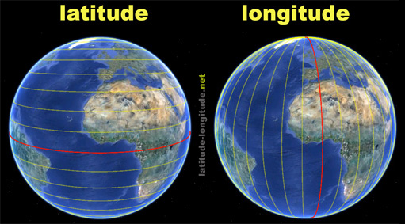

- To designate direction: sometimes positive or negative numbers, sometimes positive numbers with N/S or E/W next to them!

## Geospatial data can be tricky!

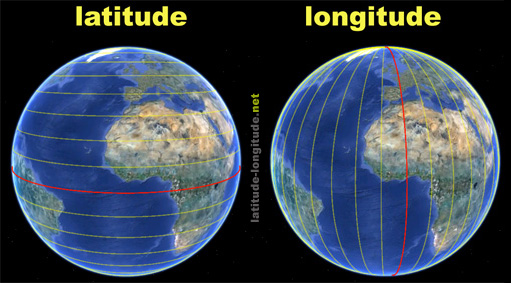

- To designate location: decimal degrees (DD), degrees minutes seconds (DMS), degrees minutes.minutes (DM.M), and sometimes even meters (*what?!*)

So… geospatial data can be **tricky**, and a bit sticky. But once you're used to it, it can be *oh so satisfying*!

## Geospatial Data and Science

- tracking animals: where do they go? how do they interact with their environment? (**today**)
- tracking flight patterns: can an airline add more flights to their schedule?
- predicting the next earth quake from previous earth quake locations
- and *so much more*!

## Imagine…

You're a marine biologist, studying fish movement patterns.

**Research questions**

- *Are bottom-feeding fish spending time near a wastewater outfall?*
- *How close are these fish to the outfall pipe?*

**Implications:**

- Fish could be exposed to harmful contaminants
- Humans that eat these fish could also be exposed

Your Study Site

A wastewater outfall ~5 mi offshore of Huntington Beach, CA

**A Quick Intro into Acoustic Telemetry**

- fish are tagged with *transmitters*
- transmitters send out a sound that's heard by underwater  
  *acoustic receivers*
- receivers record the DateTime, receiver location, and  
  tag ID # of the fish that sent the signal
- if 3+ receivers are close together and hear the same fish  
  we can get the location of the fish too

## Start with the Basics

In your toolbox:

- a shapefile with wastewater outfall location
- a shapefile with water depths (bathymetry)
- a shapefile with US states (land masses)
- tagged fish locations

*Wait, what's a shapefile?*

- A set of geospatial files (.shp, .shx, .dbf, .prj) that can map themselves
- The set must stay together, or the file breaks, but you only open the .shp

## Start with the Basics

**Step 1.** Load required packages.

```r
library(rgdal)
```

**Step 2.** Load shapefiles.

```r
outfall <- readOGR("sample-data/shapefiles/outfalls_reproject_02092016_2.shp",
                   verbose=FALSE)
depths <- readOGR("sample-data/shapefiles/all-depths.shp", verbose=FALSE)
states <- readOGR("sample-data/shapefiles/us-states.shp", verbose=FALSE)
```

## Start with the Basics

**Step 3.** Check coordinate systems.

```r
proj4string(outfall)
```

```
## [1] "+proj=longlat +datum=WGS84 +no_defs +ellps=WGS84 +towgs84=0,0,0"
```

```r
proj4string(depths)
```

```
## [1] "+proj=longlat +datum=WGS84 +no_defs +ellps=WGS84 +towgs84=0,0,0"
```

```r
proj4string(states)
```

```
## [1] "+proj=longlat +datum=NAD83 +no_defs +ellps=GRS80 +towgs84=0,0,0"
```

## Start with the Basics

For all the layers to plot nicely on top of each other, they need to all be in the **same** coordinate system.

**Step 4.** Convert coordinate systems.

```r
states <- spTransform(states, proj4string(outfall))
```

Check that the projection has properly converted

```r
proj4string(states)
```

```
## [1] "+proj=longlat +datum=WGS84 +no_defs +ellps=WGS84 +towgs84=0,0,0"
```

## Mapping to Validate Data

Now, we can quickly plot the data and see how it looks so far.

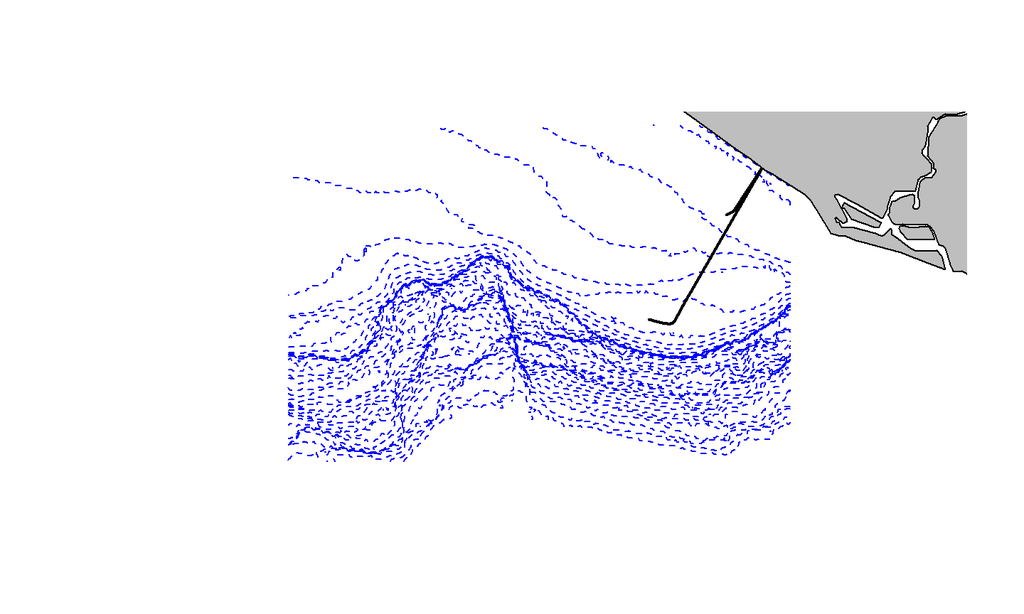

```r
plot(depths, col="blue", lty=2)
plot(outfall, col="black", lwd=2, add=TRUE)
plot(states, col="gray", add=TRUE)
```

## Loading in Fish Locations

**Step 5:** Load in fish and receiver GPS points.

```r
receiver_locations <- read.csv("sample-data/csv/receiverlocs.csv")
fish_locations <- read.csv("sample-data/csv/location_data.csv")
```

```r
head(receiver_locations, n=2)
```

```
##         Y         X Station   VR2W
## 1 33.5927 -118.0067  OCSD_1 129778
## 2 33.5909 -118.0018  OCSD_2 129789
```

```r
head(fish_locations, n=2)
```

```
##   X               times       LON      LAT
## 1 1 2017-06-16 16:16:00 -117.9986 33.58484
## 2 2 2017-06-16 16:17:00 -117.9982 33.58450
```

## Re-Formatting

For this plot, I want to be kind of fancy. I want the fish locations to be color-coded by time.

```r
# First, make sure date/time are in POSIX format
fish_locations$times <- as.POSIXct(fish_locations$times, tz="UTC",
                                   format="%Y-%m-%d %H:%M:%S")
```

```r
# Then, convert to numeric so we can add a color scheme
fish_locations$numeric_time <- as.numeric(fish_locations$times)
```

## Time to Set Up a Pretty Plot

Load in color scheme package.

```r
library(fields)
```

Set plot boundaries (trial and error)

```r
xlimits<-c(-118.076750, -117.953354) # only interested in this range of longitudes
ylimits<-c(33.558575, 33.637742) # and this range of latitudes
```

## The Final Plot Code

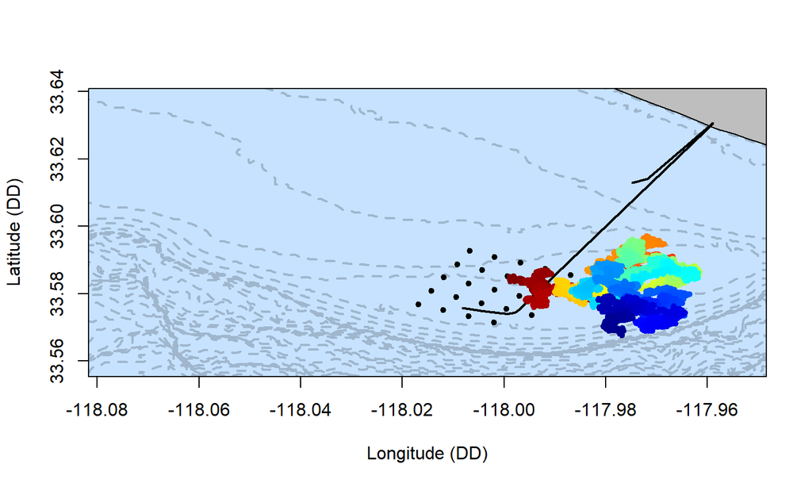

```r
# Set up empty plot
plot(receiver_locations$X, receiver_locations$Y, xlim=xlimits,
     ylim=ylimits, xlab="Longitude (DD)", ylab="Latitude (DD)", type="n")

# Create nice bluegray "base"
rect(par("usr")[1], par("usr")[3], par("usr")[2], par("usr")[4], col ="slategray1")

# Add depth contours
plot(depths, col="slategray3", lwd=2, lty=2, add=TRUE)

# Add US states
plot(states, col="gray", add=TRUE)

# Add receiver locations
points(receiver_locations$X, receiver_locations$Y, pch=20)

# Add outfall pipe
plot(outfall, lwd=2, add=TRUE)

# Re-introduce pretty boundary around the plot
rect(par("usr")[1], par("usr")[3], par("usr")[2], par("usr")[4], col ="NA")

# Add fish locations, color-coded by time
points(fish_locations$LON, fish_locations$LAT, pch=20,
       col=color.scale(fish_locations$numeric_time,zlim=range(fish_locations$numeric_time),
                        col=rev(tim.colors(256))))
```

## The Final Plot

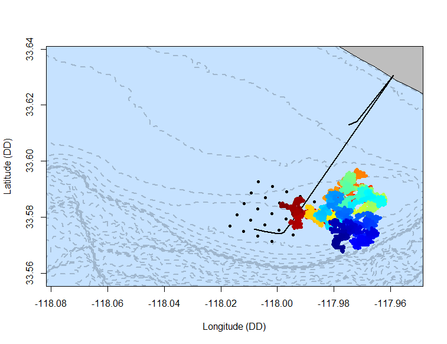

**Well Done!**

Now we can start looking at some characteristics.

We can answer questions like:

- Which depth contour is this fish spending most  
  of its time?
- *How close is this fish to the outfall pipe?*

## "Which Depths?"

In *depths* shapefile, the "field_3" gives the depth in meters

-30 == 30 meters depth

```r
library(geosphere)
```

```r
# Grab random sample (for processing speed)
random_sample <- fish_locations[sample(nrow(fish_locations), 10), ]

# Figure out the shapefile attribute that is closest to the fish gps point
distance_depths <- dist2Line(random_sample[,c("LON", "LAT")], depths)
distance_depths <- as.data.frame(distance_depths)

# Add depth column to random_sample that gives us the depth value
random_sample$depth <- depths$field_3[distance_depths$ID]
```

## "Which Depths?"

Plot it!

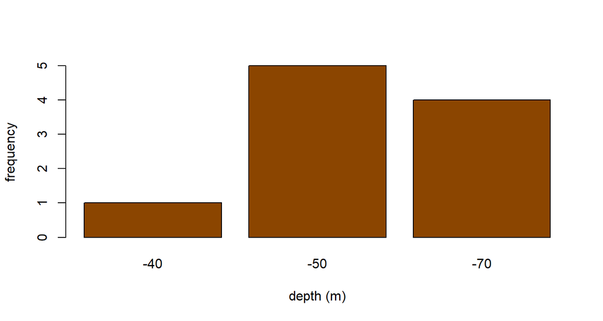

```r
distance_table <- as.data.frame(table(random_sample$depth))
barplot(height=distance_table$Freq, names.arg=rev(distance_table$Var1),
        col="darkorange4", main="", xlab="depth (m)", ylab="frequency")
```

## "How Close to the Outfall?"

Calculate the distance between fish locations and the nearest part of the outfall pipe.

```r
# Dist2Line to get distances
outfall_distance <- dist2Line(random_sample[,c("LON", "LAT")], outfall)

# Convert to data frame
outfall_distance <- as.data.frame(outfall_distance)

# Add distance (m) to the random sample data frame
random_sample$outfall_distance <- outfall_distance$distance
```

## "How Close to the Outfall?"

If this fish was using the outfall area a lot, we would see a distribution of distances that looks like this.

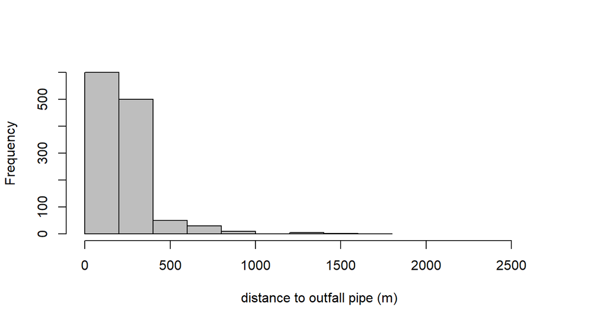

```r
# Just generate some data
expected_hist <- rep(seq(0,2750,250), c(600, 500, 50, 30, 10, 5, 2, 1, 0, 0, 0, 0))

# Plot it
hist(expected_hist, col="gray", xlab="distance to outfall pipe (m)", main="", breaks=12, xlim=c(0,2750))
```

## "How Close to the Outfall?"

How do our data compare?

[figure not shown]

```r
# Round fish locations into 250 m groups
random_sample$outfall_distance <- floor(random_sample$outfall_distance/250)*250

# Generate expected and observed plots, but don't plot them yet
expected <- hist(expected_hist, breaks=12, plot=FALSE)
obs <- hist(random_sample$outfall_distance, breaks=12, plot=FALSE)
```

## "How Close to the Outfall?"

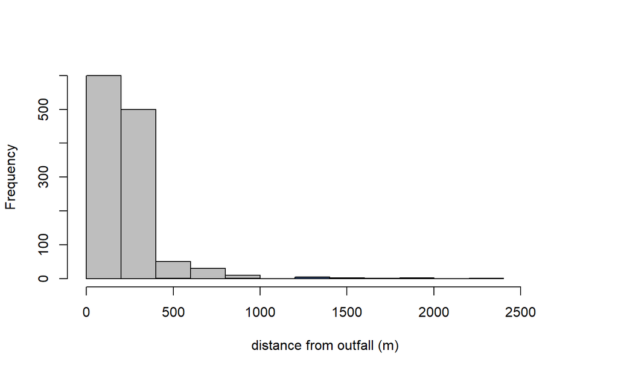

So, from this, it looks like this individual isn't regularly using the outfall pipe.

## Phew! Is there an easier way to mapping?

There always is an easier way.

*ggplot* actually has some nice features for mapping.

```r
library(tidyverse)
library(maps)
```

```r
# Get map of the world
world <- map_data("world")

# Create a ggplot map using this layer
worldplot <- ggplot() +
  geom_polygon(data = world,
               aes(x=long, y = lat, group = group), fill="gray") +
  coord_fixed(1, xlim = c(-119, -117), ylim = c(33,34)) +
  xlab("Longitude (DD)") + ylab("Latitude (DD)")

# Plot it
# worldplot
```

## Phew! Is there an easier way to mapping?

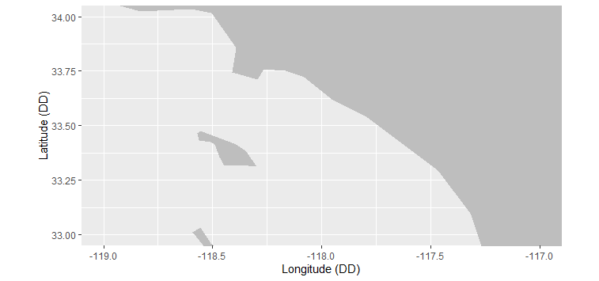

## Phew! Is there an easier way to mapping?

Let's add some fish data and re-plot it.

```r
# Add our fish data
layers <- worldplot +
  geom_point(fish_locations, mapping = aes(x=LON, y=LAT),
             color="darkorange", alpha=0.5)

# Create theme so background is blue like the ocean
new_theme <- theme(panel.background =
                     element_rect(fill = "slategray1", colour = NA),
        panel.grid.major = element_line(colour = NA),
        panel.grid.minor = element_line(colour = NA))

# Plot it
# layers + new_theme
```

## Phew! Is there an easier way to mapping?

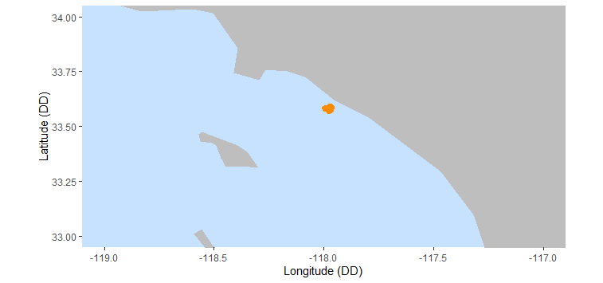

## Phew! Is there an easier way to mapping?

- *ggplot* is a lot like *matplotlib* in python
- lots of little steps to create a nice plot
- but it gets pretty tricky when you're trying to add your own shapefiles

[figure not shown]